# Session 6: Polygenic Risk Scores

Clumping, thresholding, and LDpred2 in RStudio on Biowulf

# 1 Overview

This practical introduces polygenic risk scores using chromosome 22 GWAS summary statistics, a European 1000 Genomes LD reference, simulated target genotypes, and a quantitative outcome.

We will:

1. Use PLINK 1.9 to select approximately independent variants by LD clumping.
2. Use PLINK 2 to calculate a PRS at nine GWAS p-value thresholds.
3. Select a threshold using 10,000 tuning samples.
4. Compare four LDpred2 candidates using prepared results by default, and select one in the tuning set.
5. Compare the two selected scores in 10,000 separate validation samples.

Suggested 90-minute schedule: setup (10 minutes), C+T (30), tuning discussion (10), LDpred2 (20), comparison (15), and buffer (5). Instructors should install packages, precompute the LD matrix, and run this document before class. Students start with **prepared LDpred2 results**. Optional live fitting uses the supplied LD matrix; switch `ldpred_mode` to `"fit"` to try it. Complete the session launch, required package checks, and shared-data access check before the lab. Download the LD matrix beforehand only if you plan to fit live. During class, run chunks in order **or** Knit; doing both repeats the analysis. The preparation helpers are supplied code, not exercises to rewrite.

For individual $i$, the score is
$$\mathrm{PRS}_i = \sum_{j \in S} \widehat\beta_j G_{ij},$$
where $S$ is the selected variant set, $\widehat\beta_j$ is the GWAS coefficient, and $G_{ij}$ counts copies of the **effect allele A1**. This example predicts a quantitative trait, so performance is measured with linear-regression $R^2$.

# 2 Prepare RStudio on Biowulf

Start **RStudio Server through Biowulf OnDemand** on a compute node. Start with **2 CPUs, 8 GB RAM, at least 2 hours, and 5 GB local scratch** for this chromosome 22 exercise. Select **R 4.6** to match the tested environment. The code defaults to one PLINK thread and a 2,048 MB PLINK workspace. Keep these settings within your allocation.

## 2.1 Get your own copy

In the RStudio **Terminal** tab, clone the workshop into a directory you own:

```bash
mkdir -p "/data/$USER/Stats_Gen/workshop6"
cd "/data/$USER/Stats_Gen/workshop6"
git clone https://github.com/DCEG-workshops/statgen_workshop_tutorial.git
cd statgen_workshop_tutorial/src/06_PRS
pwd
```

If you already have a clone, update it to include `src/06_PRS/` and use that folder. It contains the editable `06_PRS_LDpred2.Rmd`, the completed reference report `06_PRS_LDpred2.prepared.html`, and the prepared-score backup `06_PRS_LDpred2_prepared.rds`. Open the HTML in a browser if you want to review the finished tutorial before running it.

**Prepared mode is the default** and uses the included `06_PRS_LDpred2_prepared.rds`; it does not need the LD matrix or a download.

For optional live fitting, the `ldpred-fit` chunk automatically downloads `06_PRS_1000G_LD.rds` from GitHub if it is missing, then reuses the local file on later runs. Keep `ld_file: "06_PRS_1000G_LD.rds"` for this behavior. The 276 MiB file is a release asset, so cloning alone does not include it. To avoid download time during class, you can fetch it beforehand in the **Terminal** from `src/06_PRS/`: this downloads the supplied matrix; it does not calculate LD.

```bash
curl --fail --location --retry 3 \
  --output 06_PRS_1000G_LD.rds \
  https://github.com/DCEG-workshops/statgen_workshop_tutorial/releases/download/prs-tutorial-2026-10-27/06_PRS_1000G_LD.rds
sha256sum -c SHA256SUMS
```

Every listed file should report `OK`. Run this check before editing the Rmd; after your own edits, its checksum will differ. On macOS, use `shasum -a 256 -c SHA256SUMS`. Keep the Rmd and both RDS files together in your own writable directory. If the LD download fails, obtain the supplied file from the instructor or use prepared mode as described below.

In RStudio, select **File > Open File…** and open `06_PRS_LDpred2.Rmd` in `src/06_PRS/`. Select **Session > Set Working Directory > To Source File Location** before installing packages or running individual chunks. The Terminal’s `cd` command does not change R’s working directory. Install the packages below before running setup or clicking **Knit**.

Run **setup** in the **Initialize parameters** section below before any analysis chunk. The YAML header is configuration, not an executable R chunk; setup loads its values into `params`. Then run the remaining chunks in order, or click **Knit** to run the whole document.

## 2.2 Install and check R packages before class

Default prepared mode needs `data.table`, `knitr`, `rmarkdown`, and `Matrix`. The tested Biowulf R 4.6 module provides these core packages. The installation block below is for **optional live fitting**; skip it for prepared mode when the four core packages are already available.

Run this code once in the RStudio **Console**, with the working directory set to `src/06_PRS/`. Both `bigsnpr` and `bigsparser` need to be installed for live LDpred2 fitting. The project library is kept beside the Rmd in your own writable directory; shared workshop inputs should never be used for installation.

```r
dir.create("06_PRS_R_library", showWarnings = FALSE)
.libPaths(c(normalizePath("06_PRS_R_library"), .libPaths()))
# Precompiled packages for the tested R 4.6, RHEL 8, x86_64 environment.
repo <- "https://packagemanager.posit.co/cran/latest/bin/linux/centos8-x86_64/4.6"
install.packages(c("bigsnpr", "bigsparser"), lib = "06_PRS_R_library", repos = repo)

# Confirm all tutorial packages are available; install any missing core packages.
required <- c("data.table", "knitr", "rmarkdown", "Matrix", "bigsnpr", "bigsparser")
missing <- required[!vapply(required, requireNamespace, logical(1), quietly = TRUE)]
if (length(missing)) install.packages(missing, lib = "06_PRS_R_library", repos = repo)
stopifnot(all(vapply(required, requireNamespace, logical(1), quietly = TRUE)))
sapply(required, function(pkg) as.character(packageVersion(pkg)))
```

The six-package check is for **live fitting**. If `bigsnpr` or `bigsparser` cannot be installed, use prepared mode below. In that case, check only `data.table`, `knitr`, `rmarkdown`, and `Matrix`; the two fitting packages are not required for the backup.

Package installation is a one-time preparation step, outside the 90-minute lab; it is not rerun when knitting. The setup chunk activates this project library when present. Install packages using the **same R version** as your RStudio session. The tested versions are R 4.6.1 on Rocky Linux 8.7, `bigsnpr` 1.12.21, `bigsparser` 0.7.3, `Matrix` 1.7-5, `data.table` 1.18.6.1, `knitr` 1.52, and `rmarkdown` 2.32. They are a reproducibility reference, not exact-version checks.

The binary repository above is specific to this environment. For a different R version or operating system, use a compatible repository or `https://cloud.r-project.org`; source compilation can take substantially longer. See [Posit’s Linux binary documentation](https://packagemanager.posit.co/__docs__/admin/serving-binaries.html). This document loads `plink/1.9.0-beta4.4` for clumping and `plink/7.1-alpha` (PLINK 2) for scoring in separate shell processes.

Alternatively, from the `src/06_PRS/` directory in a **compute-node terminal**:

```bash
module load R/4.6
Rscript -e '.libPaths(c(normalizePath("06_PRS_R_library", mustWork = FALSE), .libPaths())); rmarkdown::render("06_PRS_LDpred2.Rmd")'
```

To create a code-only preview without running the analyses:

```r
rmarkdown::render("06_PRS_LDpred2.Rmd", params = list(execute = FALSE),
                  output_file = "06_PRS.preview.html")
```

## 2.3 Initialize parameters

**Run this setup chunk first in every fresh R session.** Click its green Run button, then continue with the chunks below in order. Later chunks depend on `params` and other objects created by earlier chunks.

Save any YAML edits before running setup: it reads the saved Rmd. The default confirmation is `Parameters loaded. LDpred2 mode: prepared`. If you see `object 'params' not found`, run setup before continuing. Knit supplies the parameters automatically, including overrides passed to `rmarkdown::render()`.

```r
# Activate the project library before loading knitr for interactive YAML parsing.
project_libraries <- c("06_PRS_R_binary_library", "06_PRS_R_library")
.libPaths(c(normalizePath(project_libraries[dir.exists(project_libraries)]), .libPaths()))
# Knit creates params from YAML. Running chunks directly does not.
# Reload defaults for an interactive run, including after opening an older version.
if (!isTRUE(getOption("knitr.in.progress"))) {
  input <- if (file.exists("06_PRS_LDpred2.Rmd")) "06_PRS_LDpred2.Rmd" else "06_PRS.Rmd"
  if (!file.exists(input)) stop("Set the working directory to the source file location.")
  params <- lapply(knitr::knit_params(readLines(input), evaluate = TRUE), function(x) x$value)
}
for (flag in c("execute", "run_ldpred2", "rebuild_ld")) {
  if (!is.logical(params[[flag]]) || length(params[[flag]]) != 1L || is.na(params[[flag]])) {
    stop(flag, " must be true or false in YAML.")
  }
}
knitr::opts_chunk$set(echo = TRUE, error = FALSE, warning = TRUE,
                     message = FALSE, cache = FALSE, eval = params$execute,
                     fig.width = 7, fig.height = 4.5)
cat("Parameters loaded. LDpred2 mode:", params$ldpred_mode, "\n")
```

```
## Parameters loaded. LDpred2 mode: prepared
```

## 2.4 Input files and output directory

The `data_dir` parameter points directly to the shared Biowulf folder `/data/DCEG_shared/statgen_workshop_2026/data/workshop6/data/`. Before class, confirm your account can read it and the files listed below. The raw genotypes and outcomes are not duplicated in this GitHub folder. If an access check fails, contact the instructor before beginning the lab. The `paths-and-resources` chunk checks every required input and reports any missing or unreadable file. The following raw-data files are used. The supplied LD and prepared-score files are stored separately beside this Rmd, as described above:

| Path relative to `data_dir` | Role |
| --- | --- |
| `EUR_sum_data` | Additive GWAS statistics: `CHR`, `SNP`, `BP`, `A1`, `TEST`, `NMISS`, `BETA`, `STAT`, `P` |
| `1kg_eur_22/chr_22.bed`, `.bim`, `.fam` | European LD reference |
| `prs_genotype/chr22_test.bed`, `.bim`, `.fam` | Target genotypes |
| `y_out` | Quantitative outcomes with columns `ID` and `y` |

Each run creates a new subdirectory of `06_PRS_results/` beside your copy of the tutorial. The shared inputs are read only. Change `output_dir` in the YAML header to use another writable location. Logs, scores, coefficients, the sample split, and performance tables are saved there.

```r
library(data.table)
setDTthreads(1)
if (!nzchar(Sys.getenv("SLURM_JOB_ID"))) {
  stop("Run this tutorial inside a Biowulf compute allocation.")
}
threads <- as.integer(params$threads)
allocated_cpus <- as.integer(Sys.getenv("SLURM_CPUS_PER_TASK", "1"))
if (is.na(threads) || threads < 1L || threads > allocated_cpus) {
  stop("threads must be between 1 and SLURM_CPUS_PER_TASK (or 1 if unset).")
}
memory_mb <- as.integer(params$memory_mb)
if (is.na(memory_mb) || memory_mb < 640L) stop("memory_mb must be at least 640.")
if (!is.finite(params$clump_r2) || params$clump_r2 <= 0 || params$clump_r2 >= 1 ||
    !is.finite(params$clump_kb) || params$clump_kb <= 0) {
  stop("Use 0 < clump_r2 < 1 and clump_kb > 0.")
}
Sys.setenv(OMP_NUM_THREADS = "1", OPENBLAS_NUM_THREADS = "1", MKL_NUM_THREADS = "1")

data_dir <- normalizePath(params$data_dir, mustWork = TRUE)
sum_data_file <- file.path(data_dir, "EUR_sum_data")
ref_data <- file.path(data_dir, "1kg_eur_22", "chr_22")
geno_file <- file.path(data_dir, "prs_genotype", "chr22_test")
outcome_file <- file.path(data_dir, "y_out")
inputs <- c(sum_data_file, paste0(ref_data, c(".bed", ".bim", ".fam")),
            paste0(geno_file, c(".bed", ".bim", ".fam")), outcome_file)
missing_inputs <- inputs[!file.exists(inputs) | file.access(inputs, 4) != 0]
if (length(missing_inputs)) stop("Missing/unreadable input: ",
                                 paste(missing_inputs, collapse = ", "))

output_dir <- normalizePath(path.expand(params$output_dir), mustWork = FALSE)
if (output_dir == data_dir || startsWith(output_dir, paste0(data_dir, "/"))) {
  stop("Choose an output_dir outside the shared input directory.")
}
dir.create(output_dir, recursive = TRUE, showWarnings = FALSE)
run_dir <- tempfile(pattern = paste0("run_", format(Sys.time(), "%Y%m%d_%H%M%S"), "_"),
                    tmpdir = output_dir)
if (!dir.create(run_dir)) stop("Cannot create a results directory: ", run_dir)
run_dir <- normalizePath(run_dir)
saveRDS(params, file.path(run_dir, "parameters.rds"))
writeLines(c(paste("Host:", Sys.info()[["nodename"]]),
             paste("Job:", Sys.getenv("SLURM_JOB_ID")),
             paste("Working directory:", getwd()),
             paste("Started:", Sys.time())), file.path(run_dir, "run_info.txt"))
knitr::kable(data.frame(input = sub(paste0(data_dir, "/"), "", inputs, fixed = TRUE),
                        MB = round(file.info(inputs)$size / 1024^2, 2)))
```

| input | MB |
| --- | --- |
| EUR_sum_data | 8.31 |
| 1kg_eur_22/chr_22.bed | 133.41 |
| 1kg_eur_22/chr_22.bim | 40.58 |
| 1kg_eur_22/chr_22.fam | 0.01 |
| prs_genotype/chr22_test.bed | 117.53 |
| prs_genotype/chr22_test.bim | 0.96 |
| prs_genotype/chr22_test.fam | 0.44 |
| y_out | 0.31 |

```r
cat("Results directory:", run_dir, "\n")
```

```
## Results directory: /vf/users/wongs6/statgen_workshop_2026/PRS_tutorial_Wendy_2026-10-27/publishing/interactive_setup_2026-10-28/prepared_results/run_20261028_110801_2526d71a729ffa
```

## 2.5 Run PLINK from R

This helper loads the appropriate Biowulf module in a child shell, records the command and its output, and stops if PLINK fails. Switching PLINK versions does not change the RStudio environment.

```r
run_plink <- function(version, args, label) {
  module_name <- switch(version, "1" = "plink/1.9.0-beta4.4", "2" = "plink/7.1-alpha")
  binary <- switch(version, "1" = "plink", "2" = "plink2")
  if (is.null(module_name)) stop("Unknown PLINK version.")
  command <- paste(c(binary, shQuote(as.character(args))), collapse = " ")
  script <- file.path(run_dir, paste0(label, ".sh"))
  log <- file.path(run_dir, paste0(label, ".console.log"))
  writeLines(c("#!/bin/bash", "set -eo pipefail",
               "if ! type module >/dev/null 2>&1; then source /etc/profile.d/modules.sh; fi",
               paste("module load", shQuote(module_name)), command), script)
  status <- system2("bash", shQuote(script), stdout = log, stderr = log)
  if (status != 0L) stop("PLINK failed; inspect ", log)
  invisible(log)
}
version_logs <- c(run_plink("1", "--version", "plink1_version"),
                  run_plink("2", "--version", "plink2_version"))
cat(unlist(lapply(version_logs, readLines)), sep = "\n")
```

```
## [+] Loading plink  1.9.0-beta4.4  on cn1073
## PLINK v1.90b4.4 64-bit (21 May 2017)
## [+] Loading plink  7.1-alpha
## PLINK v2.0.0-a.7.1LM 64-bit Intel (4 May 2026)
```

```r
resource_args <- c("--threads", threads, "--memory", memory_mb)
```

# 3 Inspect the summary statistics and outcomes

`BETA` is the effect per copy of `A1`; it is not an odds ratio. The supplied files are prepared with consistent variant identifiers and allele coding. For another dataset, verify genome build, strand, both alleles, and independence of discovery and target samples before scoring. Matching an rsID alone is insufficient to establish allele alignment.

```r
EUR_sum <- fread(sum_data_file, colClasses = c(SNP = "character", A1 = "character"))
required_columns <- c("CHR", "SNP", "BP", "A1", "TEST", "NMISS", "BETA", "STAT", "P")
if (!all(required_columns %in% names(EUR_sum))) stop("Summary-statistic columns are missing.")
if (anyDuplicated(EUR_sum$SNP)) stop("Duplicate summary SNP IDs.")

fam <- fread(paste0(geno_file, ".fam"), header = FALSE, colClasses = "character")
setnames(fam, c("FID", "IID", "father", "mother", "sex", "phenotype"))
y_out <- fread(outcome_file, colClasses = c(ID = "character"))
if (!all(c("ID", "y") %in% names(y_out))) stop("y_out must contain ID and y.")
if (nrow(y_out) != 20000L || nrow(fam) != 20000L ||
    anyNA(y_out$ID) || anyNA(fam$IID) || anyDuplicated(y_out$ID) ||
    anyDuplicated(fam$IID) || !setequal(y_out$ID, fam$IID) ||
    any(!is.finite(y_out$y))) {
  stop("Expected 20,000 finite outcomes and uniquely matching target IIDs.")
}
# Preserve phenotype order for the split; attach genotype identifiers explicitly.
samples <- data.table(FID = fam$FID[match(y_out$ID, fam$IID)],
                      IID = y_out$ID, y = y_out$y,
                      cohort = rep(c("tuning", "validation"), each = 10000L))
fwrite(samples[, .(FID, IID, cohort)], file.path(run_dir, "sample_split.tsv"), sep = "\t")
knitr::kable(data.frame(summary_variants = nrow(EUR_sum), target_samples = nrow(samples),
                        tuning_samples = sum(samples$cohort == "tuning"),
                        validation_samples = sum(samples$cohort == "validation")))
```

| summary_variants | target_samples | tuning_samples | validation_samples |
| --- | --- | --- | --- |
| 121435 | 20000 | 10000 | 10000 |

The first 10,000 rows of `y_out` form the tuning set and the last 10,000 form the validation set. In the supplied data these are IDs 100001 to 110000 and 110001 to 120000, respectively. Do not use validation outcomes to choose either method’s parameters.

# 4 Prepare one eligible variant pool for both methods

LDpred2 needs both alleles, standard errors, and GWAS sample sizes in addition to effect estimates. The supplied PLINK `ADD` results report the signed test statistic, so we reconstruct $\mathrm{SE}=\mathrm{BETA}/\mathrm{STAT}$. Rows with undefined or nonpositive SE are excluded. `NMISS` supplies the per-variant discovery sample size for this quantitative trait, not the target or reference sample size. Rounded input statistics make the reconstructed SE approximate; use the original SE column when available in a new study.

These particular SNP IDs encode position and both alleles, for example `rs62224609:16051249:T:C`. The helper below is specific to that convention. It checks exact IDs, coordinates, and allele pairs against both genotype files, removes palindromic SNPs and duplicate positions, and aligns effects to reference allele1. It does not infer strand flips or genome builds. A new dataset requires its own harmonization workflow.

Both methods start with this **unclumped** common pool. C+T then selects a subset; LDpred2 uses joint LD information to shrink effects across the pool. Clumping after restricting to target variants avoids choosing a lead SNP that cannot be scored and then losing its available correlated alternatives.

```r
read_bim <- function(prefix) {
  x <- fread(paste0(prefix, ".bim"), header = FALSE, colClasses = "character")
  setnames(x, c("CHR", "SNP", "CM", "BP", "allele1", "allele2"))
  x
}
# Subset the large reference with PLINK before reading its BIM into R.
# This avoids importing variants that cannot enter either score.
target_bim <- read_bim(geno_file)
initial_ids <- intersect(EUR_sum$SNP, target_bim$SNP)
if (!length(initial_ids)) stop("No shared summary and target SNP IDs.")
initial_file <- file.path(run_dir, "initial_shared_ids.txt")
writeLines(initial_ids, initial_file)
initial_ref <- file.path(run_dir, "initial_reference")
run_plink("1", c("--bfile", ref_data, "--extract", initial_file,
                 "--keep-allele-order", "--make-bed", resource_args,
                 "--out", initial_ref), "initial_reference_subset")
ref_bim <- read_bim(initial_ref)
prepared <- prepare_candidates(EUR_sum, ref_bim, target_bim)
manifest <- prepared$manifest
if (any(manifest$CHR != "22")) stop("This exercise expects chromosome 22 only.")
if (!is.finite(params$ref_maf) || params$ref_maf <= 0 || params$ref_maf >= .5 ||
    !is.finite(params$ref_geno) || params$ref_geno < 0 || params$ref_geno > 1) {
  stop("Invalid reference QC parameters.")
}
candidate_file <- file.path(run_dir, "candidate_snps.txt")
writeLines(manifest$SNP, candidate_file)
common_ref <- file.path(run_dir, "common_reference")
run_plink("1", c("--bfile", initial_ref, "--extract", candidate_file,
                 "--maf", params$ref_maf, "--geno", params$ref_geno,
                 "--keep-allele-order", "--make-bed", resource_args,
                 "--out", common_ref), "reference_qc")
common_bim <- read_bim(common_ref)
if (!nrow(common_bim) || !all(common_bim$SNP %in% manifest$SNP)) {
  stop("Unexpected reference subset.")
}
n_before_qc <- nrow(manifest)
manifest <- manifest[match(common_bim$SNP, manifest$SNP)]
stopifnot(identical(manifest$A1, common_bim$allele1),
          identical(manifest$A2, common_bim$allele2),
          all(diff(manifest$BP) > 0))
audit <- rbind(prepared$audit, data.table(stage = "reference_qc",
  reason = "Reference MAF and genotype missingness filters.",
  before = n_before_qc, removed = n_before_qc - nrow(manifest),
  retained = nrow(manifest)))
fwrite(audit, file.path(run_dir, "variant_audit.tsv"), sep = "\t")
fwrite(manifest, file.path(run_dir, "variant_manifest.tsv"), sep = "\t")
common_sum_file <- file.path(run_dir, "common_summary.tsv")
fwrite(manifest, common_sum_file, sep = "\t")
knitr::kable(audit[, .(stage, before, removed, retained)])
```

| stage | before | removed | retained |
| --- | --- | --- | --- |
| additive_tests | 121435 | 0 | 121435 |
| shared_ids | 121435 | 96787 | 24648 |
| matching_coordinates | 24648 | 0 | 24648 |
| composite_ids | 24648 | 0 | 24648 |
| biallelic_snps | 24648 | 0 | 24648 |
| unambiguous_alleles | 24648 | 1096 | 23552 |
| matching_alleles | 23552 | 0 | 23552 |
| unique_positions | 23552 | 0 | 23552 |
| valid_statistics | 23552 | 0 | 23552 |
| reference_qc | 23552 | 0 | 23552 |

```r
cat("Eligible variants:", nrow(manifest),
    "\nReference individuals:", nrow(fread(paste0(common_ref, ".fam"))),
    "\nEffects reversed to reference allele1:", sum(manifest$beta_reversed), "\n")
```

```
## Eligible variants: 23552
## Reference individuals: 503
## Effects reversed to reference allele1: 30
```

The reference MAF filter removes monomorphic and very rare reference variants; the genotype missingness filter limits missing calls. The LD matrix below uses pairwise complete reference genotypes. These choices are fixed before tuning.

# 5 LD clumping with PLINK 1.9

Clumping selects a lead SNP and groups nearby SNPs correlated with it, starting with the smallest GWAS p-value. We use a **500 kb radius**, **LD $r^2 = 0.1$**, and `--clump-p1 1` so index SNPs across the p-value range can be considered. LD $r^2$ measures correlation between variants and differs from the prediction $R^2$ calculated later.

```r
clump_prefix <- file.path(run_dir, "LD_clump")
run_plink("1", c("--bfile", common_ref, "--clump", common_sum_file,
                 "--clump-p1", "1", "--clump-r2", params$clump_r2,
                 "--clump-kb", params$clump_kb,
                 resource_args, "--out", clump_prefix), "clumping")
clump_file <- paste0(clump_prefix, ".clumped")
if (!file.exists(clump_file)) stop("No clumps were produced; inspect the PLINK log.")
LD_clump <- fread(clump_file)
if (!"SNP" %in% names(LD_clump) || !nrow(LD_clump)) stop("No lead SNPs were found.")
clumped <- manifest[match(LD_clump$SNP, manifest$SNP), .(SNP, A1, BETA, P)]
if (anyNA(clumped)) stop("Clumped SNPs did not match the common variant pool.")
prs_prep <- copy(clumped)
cat("LD-clumped lead SNPs:", nrow(clumped), "\n")
```

```
## LD-clumped lead SNPs: 3108
```

```r
setorder(prs_prep, P, SNP)
fwrite(prs_prep, file.path(run_dir, "clumped_score_candidates.tsv"), sep = "\t")
knitr::kable(head(prs_prep)[, .(SNP, A1, BETA, P = format(P, scientific = TRUE))])
```

| SNP | A1 | BETA | P |
| --- | --- | --- | --- |
| rs2038326:26189026:T:C | T | -0.03894 | 3.274e-15 |
| rs738697:49026230:T:C | C | 0.03544 | 2.895e-12 |
| rs115190708:27025717:A:G | G | -0.04019 | 3.667e-09 |
| rs135110:32463875:G:A | G | 0.02627 | 8.934e-09 |
| rs5755809:36038700:C:A | A | -0.07251 | 8.494e-08 |
| rs79478:44582499:T:C | T | 0.06688 | 1.022e-07 |

# 6 Calculate PRS at nine p-value thresholds

For each threshold, retain clumped SNPs with `P <= threshold` and write their `SNP`, `A1`, and `BETA` values. `header` skips the coefficient-file header; `1 2 3` identifies the input columns. `SCORE1_SUM` is the weighted allele sum. With `no-mean-imputation`, a missing genotype contributes no term to the sum. Missingness can affect scores in real data.

All clumped lead SNPs come from the common eligible pool and should be scoreable. The code verifies the actual variants used by PLINK at every threshold.

```r
pthres <- c(5e-8, 5e-7, 5e-6, 5e-5, 5e-4, 5e-3, 5e-2, 5e-1, 1)
performance <- data.table(threshold = pthres, n_lead_snps = 0L, n_scored_snps = 0L,
                           tuning_R2 = NA_real_, status = "not scored")
for (k in seq_along(pthres)) {
  prs_coeff <- prs_prep[P <= pthres[k], .(SNP, A1, BETA)]
  performance$n_lead_snps[k] <- sum(clumped$P <= pthres[k])
  performance$n_scored_snps[k] <- nrow(prs_coeff)
  if (!nrow(prs_coeff)) {
    performance$status[k] <- "no SNPs at this threshold"
    next
  }
  coefficient_file <- file.path(run_dir, paste0("prs_coeff_", k, ".tsv"))
  score_prefix <- file.path(run_dir, paste0("prs_", k))
  fwrite(prs_coeff, coefficient_file, sep = "\t")
  run_plink("2", c("--bfile", geno_file,
                   "--score", coefficient_file, "1", "2", "3", "header",
                   "no-mean-imputation", "list-variants", "cols=+fid,+scoresums,-scoreavgs",
                   resource_args, "--out", score_prefix), paste0("scoring_", k))
  used_snps <- readLines(paste0(score_prefix, ".sscore.vars"))
  if (!setequal(used_snps, prs_coeff$SNP)) stop("PLINK skipped scoring variants; inspect its log.")
  performance$status[k] <- "scored"
}
knitr::kable(performance[, .(threshold = format(threshold, scientific = TRUE),
                              n_lead_snps, n_scored_snps, status)])
```

| threshold | n_lead_snps | n_scored_snps | status |
| --- | --- | --- | --- |
| 5e-08 | 4 | 4 | scored |
| 5e-07 | 10 | 10 | scored |
| 5e-06 | 11 | 11 | scored |
| 5e-05 | 17 | 17 | scored |
| 5e-04 | 32 | 32 | scored |
| 5e-03 | 95 | 95 | scored |
| 5e-02 | 440 | 440 | scored |
| 5e-01 | 2173 | 2173 | scored |
| 1e+00 | 3108 | 3108 | scored |

# 7 Select the threshold using the tuning set

Read scores by **FID and IID**, and reorder them to match the outcome table. An empty SNP set or a constant score cannot be evaluated and is excluded from threshold selection. Validation outcomes are not used here.

```r
read_score_file <- function(path) {
  scores <- fread(path,
                   colClasses = "character")
  setnames(scores, sub("^#", "", names(scores)))
  if (!all(c("FID", "IID", "SCORE1_SUM") %in% names(scores))) {
    stop("Missing expected columns in PLINK score output.")
  }
  key <- paste(scores$FID, scores$IID, sep = "\t")
  expected_key <- paste(samples$FID, samples$IID, sep = "\t")
  if (anyDuplicated(key) || !setequal(key, expected_key)) {
    stop("Scored sample IDs do not match the outcomes.")
  }
  score <- as.numeric(scores$SCORE1_SUM[match(expected_key, key)])
  if (any(!is.finite(score))) stop("Non-finite PRS values.")
  score
}
read_scores <- function(k) read_score_file(file.path(run_dir, paste0("prs_", k, ".sscore")))
tuning <- samples$cohort == "tuning"
if (var(samples$y[tuning]) == 0) stop("The tuning outcome is constant.")
for (k in which(performance$status == "scored")) {
  score <- read_scores(k)
  if (var(score[tuning]) == 0) {
    performance$status[k] <- "constant tuning score"
    next
  }
  model <- lm(y ~ PRS, data = data.frame(y = samples$y[tuning], PRS = score[tuning]))
  performance$tuning_R2[k] <- summary(model)$r.squared
}
eligible <- which(is.finite(performance$tuning_R2))
if (!length(eligible)) stop("No threshold produced an evaluable tuning score.")
# Thresholds are ascending; a tie selects the smaller threshold.
best_k <- eligible[which.max(performance$tuning_R2[eligible])]
fwrite(performance, file.path(run_dir, "tuning_performance.tsv"), sep = "\t")
performance_display <- copy(performance)
performance_display[, threshold := format(threshold, scientific = TRUE)]
knitr::kable(performance_display, digits = 6)
```

| threshold | n_lead_snps | n_scored_snps | tuning_R2 | status |
| --- | --- | --- | --- | --- |
| 5e-08 | 4 | 4 | 0.001805 | scored |
| 5e-07 | 10 | 10 | 0.003145 | scored |
| 5e-06 | 11 | 11 | 0.002991 | scored |
| 5e-05 | 17 | 17 | 0.003413 | scored |
| 5e-04 | 32 | 32 | 0.003622 | scored |
| 5e-03 | 95 | 95 | 0.002676 | scored |
| 5e-02 | 440 | 440 | 0.001650 | scored |
| 5e-01 | 2173 | 2173 | 0.001172 | scored |
| 1e+00 | 3108 | 3108 | 0.001080 | scored |

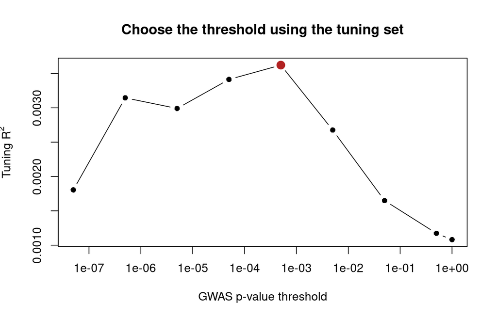

```r
plot(performance$threshold, performance$tuning_R2, log = "x", type = "b", pch = 16,
     xlab = "GWAS p-value threshold", ylab = expression("Tuning " * R^2),
     main = "Choose the threshold using the tuning set")
points(performance$threshold[best_k], performance$tuning_R2[best_k],
       pch = 19, col = "firebrick", cex = 1.5)
```

# 8 Compare LDpred2 using the same data

## 8.1 What changes from C+T?

C+T keeps selected marginal GWAS effects after clumping. LDpred2 models correlation between variants and estimates posterior effects under a prior that combines zero and nonzero effects. We keep correlated SNPs in the eligible pool and provide their LD matrix.

This exercise uses a small, prespecified grid:

| Parameter | Values | Meaning |
| --- | --- | --- |
| `p` | 0.01, 0.1 | Prior proportion of causal variants in the modeled pool |
| `h2` | 0.01, 0.1 | Candidate proportion of phenotype variance explained by the modeled pool |
| `sparse` | `FALSE` | Do not request the additional sparse solution |

These `h2` values are teaching settings, not estimates of whole-genome heritability. A chromosome 22 subset cannot be assigned a whole-genome heritability without justification. The grid is deliberately small for the lab and must be fixed before examining validation outcomes. The four-model grid omits `p = 1` because its dense Gibbs updates are slow in this example. For an instructor extension, add `p = 1` before examining validation results and generate a new matching prepared backup.

We use a 3,000 kb LD radius and shrink off-diagonal correlations by 0.95 to stabilize the small reference matrix. Physical distance is used because these files do not provide an appropriate genetic map. This is not a 3 cM window. For research, use the method’s recommended LD resources, broader parameter search, and convergence checks. This small example does not establish that one method predicts better in general.

## 8.2 Choose prepared results or live fitting

Keep these default YAML settings to use the prepared LDpred2 results:

```yaml
execute: true
run_ldpred2: true
ldpred_mode: "prepared"
rebuild_ld: false
```

Save any YAML edits before rerunning setup or knitting. The default loads prepared weights and scores; C+T still runs live. To fit LDpred2 yourself, change **only** `ldpred_mode` to `"fit"` and install the fitting packages above.

For optional live fitting, the instructor supplies `06_PRS_1000G_LD.rds`, computed from the same 1000 Genomes reference and eligible variants. Students load this LD matrix and run LDpred2; they do not calculate LD during class. Set `ld_file` to its path if it is stored elsewhere. A missing default file is downloaded from the GitHub release; a missing custom path or an incompatible file stops the fit. LD is never calculated unless you explicitly set `rebuild_ld: true`.

The two supplied RDS files have different purposes:

| File | Contents | Classroom use |
| --- | --- | --- |
| `06_PRS_1000G_LD.rds` | LD matrix, ordered alleles, reference checksums, and settings | Input for optional live fitting |
| `06_PRS_LDpred2_prepared.rds` | Fitted weights and target scores, with matching metadata | Default; skips LDpred2 fitting and scoring |

A successful fit saves `ldpred2_prepared.rds` in the run directory, including weights, scores, settings, input checksums, and software versions. The instructor can distribute that file as `06_PRS_LDpred2_prepared.rds`, together with this Rmd and the same input data.

In the original instructor test, the LDpred2 section took about **6 minutes**, the full live document about **11 minutes**, and the prepared document about **4 minutes**. A later test on another Biowulf node was much faster; runtime varies with the node and storage. Allow up to ten minutes for the LD loading and fitting chunk during class. If it is still running at that point, stop the active chunk and wait for the Console prompt. Set `ldpred_mode: "prepared"` and `prepared_ldpred_file` to the instructor’s RDS path, then **save the Rmd**. When running chunks, rerun `setup`, `ldpred-config`, `ldpred-fit`, and `ldpred-score-tune`, using the C+T results already in the current session. Then continue to validation and score comparison. In a fresh session, run all chunks or Knit. For a fresh prepared run, keep the default `ldpred_mode: "prepared"` and run all chunks or Knit. If switching back from live fitting, change only that mode and save. Keep the model grid and data settings unchanged: the fallback checks the input files, variant order, settings, and sample IDs. It explicitly reports that results were loaded. It does not require the LD file, `bigsnpr`, or `bigsparser` to be installed. To run only C+T, set `run_ldpred2: false`.

```r
if (!params$ldpred_mode %in% c("fit", "prepared")) stop("Use fit or prepared mode.")
if (!length(params$ldpred_p) || !length(params$ldpred_h2) || any(!is.finite(params$ldpred_p)) || any(params$ldpred_p <= 0 | params$ldpred_p > 1) ||
    any(!is.finite(params$ldpred_h2)) || any(params$ldpred_h2 <= 0 | params$ldpred_h2 > 1) ||
    !is.finite(params$ld_window_kb) || params$ld_window_kb <= 0 ||
    !is.finite(params$ld_shrink) || params$ld_shrink <= 0 || params$ld_shrink > 1 ) stop("Invalid LDpred2 settings.")
for (parameter in c("ldpred_burn_in", "ldpred_num_iter", "ldpred_seed")) {
  value <- params[[parameter]]
  if (length(value) != 1L || !is.numeric(value) || !is.finite(value) ||
      value != floor(value) || value < 1 || value > .Machine$integer.max) {
    stop(parameter, " must be a positive integer.")
  }
}
# Do not name this table params: that name belongs to R Markdown's YAML list.
ldpred_grid <- as.data.table(expand.grid(p = params$ldpred_p, h2 = params$ldpred_h2,
                                        sparse = FALSE, KEEP.OUT.ATTRS = FALSE))
ldpred_grid[, model := paste0("LD", seq_len(.N))]
ldpred_settings <- params[c("ld_window_kb", "ld_shrink", "ref_maf", "ref_geno",
                           "ldpred_p", "ldpred_h2", "ldpred_burn_in",
                           "ldpred_num_iter", "ldpred_seed")]
# Record the effective mode/settings when switching to the prepared fallback.
saveRDS(params, file.path(run_dir, "parameters_effective.rds"))
input_md5 <- unname(tools::md5sum(inputs))
names(input_md5) <- c("summary", "ref_bed", "ref_bim", "ref_fam",
                     "target_bed", "target_bim", "target_fam", "outcomes")
knitr::kable(ldpred_grid)
```

| p | h2 | sparse | model |
| --- | --- | --- | --- |
| 0.01 | 0.01 | FALSE | LD1 |
| 0.10 | 0.01 | FALSE | LD2 |
| 0.01 | 0.10 | FALSE | LD3 |
| 0.10 | 0.10 | FALSE | LD4 |

```r
cat("LDpred2 mode:", params$ldpred_mode, "\n")
```

```
## LDpred2 mode: prepared
```

## 8.3 Load the supplied LD matrix and estimate joint weights

For the live exercise, inspect the four-row grid, run the fit, and then run the scoring and tuning chunk. Record the selected `p` and `h2` before opening the validation results. The preparation helper is supplied code; students do not need to rewrite it during the lab.

The rows and columns of the LD matrix, summary-statistic rows, and genotype columns must have exactly the same order and allele coding. `bigsnpr` counts reference allele1; our manifest is aligned to that allele. The assertions below are part of the analysis, not optional checks.

The supplied matrix already includes the stated 0.95 shrinkage. The loader checks this flag and the settings and does not apply shrinkage again. The optional instructor appendix shows how to rebuild this file before class.

```r
ldpred_timing <- data.table(step = character(), seconds = numeric())
if (params$ldpred_mode == "prepared") {
  backup_file <- path.expand(params$prepared_ldpred_file)
  if (!nzchar(backup_file) || !file.exists(backup_file)) stop("Provide the prepared RDS file.")
  backup <- readRDS(backup_file)
  if (!identical(backup$schema, 1L) || !identical(backup$input_md5, input_md5) ||
      !identical(backup$settings, ldpred_settings) ||
      !identical(backup$manifest, as.data.frame(manifest)) ||
      !identical(backup$grid, as.data.frame(ldpred_grid))) {
    stop("Prepared results do not match these inputs, variants, or settings.")
  }
  ldpred_weights <- backup$weights
  fit_status <- backup$fit_status
  fit_versions <- backup$versions
  ldpred_timing <- as.data.table(backup$timing)
  cat("Loaded prepared LDpred2 weights and scores from:", backup_file, "\n")
} else {
  needed <- c("bigsnpr", "bigsparser", "Matrix")
  missing <- needed[!vapply(needed, requireNamespace, logical(1), quietly = TRUE)]
  if (length(missing)) stop("Install before class: ", paste(missing, collapse = ", "),
                            "; or switch to prepared mode.")
  if (!is.character(params$ld_file) || length(params$ld_file) != 1L ||
      is.na(params$ld_file) || !nzchar(params$ld_file)) stop("Set ld_file to the supplied LD RDS path.")
  ld_path <- path.expand(params$ld_file)
  if (isTRUE(params$rebuild_ld)) {
    build_start <- proc.time()[["elapsed"]]
    ld_bundle <- build_ld_bundle(common_ref, manifest, params, input_md5, threads, run_dir)
    saveRDS(ld_bundle, ld_path)
    ldpred_timing <- rbind(ldpred_timing, data.table(step = "Build LD (instructor only)",
      seconds = proc.time()[["elapsed"]] - build_start))
    cat("Saved instructor LD matrix:", ld_path, "\n")
  }
  if (!file.exists(ld_path) && identical(params$ld_file, "06_PRS_1000G_LD.rds")) {
    # Download the supplied matrix once; keep incomplete downloads out of the cache.
    (function() {
      old_options <- options(timeout = max(600, getOption("timeout")))
      on.exit(options(old_options), add = TRUE)
      download_path <- tempfile("LD_download_", tmpdir = dirname(ld_path), fileext = ".rds")
      on.exit(unlink(download_path), add = TRUE)
      cat("Downloading supplied LD matrix from GitHub...\n")
      download.file(
        "https://github.com/DCEG-workshops/statgen_workshop_tutorial/releases/download/prs-tutorial-2026-10-27/06_PRS_1000G_LD.rds",
        destfile = download_path, mode = "wb")
      expected_sha256 <- "49705b768abc564e361f64f4de5384b9d90a64ec11d65a2fe9cacfefff78c35a"
      if (!identical(digest::digest(file = download_path, algo = "sha256"), expected_sha256)) {
        stop("Downloaded LD checksum mismatch; retry or use prepared mode.")
      }
      if (!file.rename(download_path, ld_path)) stop("Cannot save downloaded LD file: ", ld_path)
    })()
  }
  if (!file.exists(ld_path)) {
    stop("Missing precomputed LD file: ", ld_path,
         ". Obtain it from the instructor or use prepared-score mode.")
  }
  ld_start <- proc.time()[["elapsed"]]
  ld_bundle <- readRDS(ld_path)
  validate_ld_bundle(ld_bundle, manifest, params, input_md5)
  corr_sparse <- ld_bundle$corr  # Already shrunk; do not shrink a second time.
  ld_tmpdir <- choose_ld_tempdir()
  corr <- bigsparser::as_SFBM(corr_sparse,
                            backingfile = tempfile("LD_matrix_", tmpdir = ld_tmpdir), compact = TRUE)
  cat("Temporary LD backing file:", corr$sbk, "\n")
  ldpred_timing <- rbind(ldpred_timing, data.table(step = "Load LD and create SFBM",
                                                 seconds = proc.time()[["elapsed"]] - ld_start))
  cat("Loaded precomputed LD for", nrow(corr_sparse), "variants from:", ld_path,
      "\nLD created:", ld_bundle$created, "\n")
  df_beta <- data.frame(beta = manifest$BETA, beta_se = manifest$SE,
                        n_eff = manifest$NMISS)
  fit_start <- proc.time()[["elapsed"]]
  set.seed(params$ldpred_seed)
  ldpred_weights <- bigsnpr::snp_ldpred2_grid(
    corr, df_beta, grid_param = as.data.frame(ldpred_grid[, .(p, h2, sparse)]),
    burn_in = params$ldpred_burn_in, num_iter = params$ldpred_num_iter,
    ncores = threads)
  ldpred_timing <- rbind(ldpred_timing, data.table(step = "LDpred2 fitting",
                                                 seconds = proc.time()[["elapsed"]] - fit_start))
  ldpred_weights <- as.matrix(ldpred_weights)
  fit_status <- ifelse(colSums(!is.finite(ldpred_weights)) == 0, "finite weights", "nonfinite weights")
  fit_versions <- vapply(needed, function(pkg) as.character(packageVersion(pkg)), character(1))
}
```

```
## Loaded prepared LDpred2 weights and scores from: 06_PRS_LDpred2_prepared.rds
```

```r
stopifnot(identical(dim(ldpred_weights), c(nrow(manifest), nrow(ldpred_grid))))
fit_status <- ifelse(colSums(!is.finite(ldpred_weights)) == 0, "finite weights", "nonfinite weights")
if (!any(fit_status == "finite weights")) stop("All LDpred2 fits failed.")
colnames(ldpred_weights) <- ldpred_grid$model
rownames(ldpred_weights) <- manifest$SNP
knitr::kable(cbind(ldpred_grid, fit_status))
```

| p | h2 | sparse | model | fit_status |
| --- | --- | --- | --- | --- |
| 0.01 | 0.01 | FALSE | LD1 | finite weights |
| 0.10 | 0.01 | FALSE | LD2 | finite weights |
| 0.01 | 0.10 | FALSE | LD3 | nonfinite weights |
| 0.10 | 0.10 | FALSE | LD4 | nonfinite weights |

Nonfinite coefficients indicate a failed model and exclude it from tuning. Finite coefficients alone do not establish MCMC convergence. The short run is for teaching; a research analysis needs longer runs and stability assessment. In the supplied instructor backup, both `h2 = 0.1` candidates have nonfinite weights and are excluded. The two `h2 = 0.01` candidates can be scored. Inspect these statuses before selecting a model; an excluded candidate has zero scored SNPs and no tuning R-squared.

## 8.4 Score the target samples and tune LDpred2

The score formula stays the same. We replace the marginal GWAS coefficients with LDpred2 posterior coefficients. PLINK uses the specified effect allele even when the target BIM lists its alleles in the opposite order. Both methods use `SCORE1_SUM` and the same missing-genotype policy.

```r
score_start <- proc.time()[["elapsed"]]
ldpred_scores <- matrix(NA_real_, nrow(samples), nrow(ldpred_grid),
                         dimnames = list(NULL, ldpred_grid$model))
if (params$ldpred_mode == "prepared") {
  expected_key <- paste(samples$FID, samples$IID, sep = "\t")
  saved_key <- paste(backup$scores$FID, backup$scores$IID, sep = "\t")
  if (anyDuplicated(saved_key) || !setequal(saved_key, expected_key) ||
      !all(ldpred_grid$model %in% names(backup$scores))) stop("Prepared scores have incompatible IDs.")
  ldpred_scores[,] <- as.matrix(backup$scores[match(expected_key, saved_key), ldpred_grid$model, drop = FALSE])
} else {
  for (j in which(fit_status == "finite weights")) {
    weights_file <- file.path(run_dir, paste0("ldpred2_weights_", j, ".tsv"))
    score_prefix <- file.path(run_dir, paste0("ldpred2_", j))
    fwrite(data.table(SNP = manifest$SNP, A1 = manifest$A1,
                      BETA = ldpred_weights[, j]), weights_file, sep = "\t")
    run_plink("2", c("--bfile", geno_file, "--score", weights_file, "1", "2", "3", "header",
                     "no-mean-imputation", "list-variants", "cols=+fid,+scoresums,-scoreavgs",
                     resource_args, "--out", score_prefix), paste0("ldpred2_scoring_", j))
    if (!setequal(readLines(paste0(score_prefix, ".sscore.vars")), manifest$SNP)) {
      stop("PLINK skipped an LDpred2 scoring variant.")
    }
    ldpred_scores[, j] <- read_score_file(paste0(score_prefix, ".sscore"))
  }
  ldpred_timing <- rbind(ldpred_timing, data.table(step = "Target scoring",
    seconds = proc.time()[["elapsed"]] - score_start))
}
ldpred_performance <- copy(ldpred_grid)
ldpred_performance[, `:=`(n_scored_snps = ifelse(fit_status == "finite weights", nrow(manifest), 0L),
                          tuning_R2 = NA_real_, status = fit_status)]
for (j in which(fit_status == "finite weights")) {
  score <- ldpred_scores[, j]
  if (any(!is.finite(score)) || var(score[tuning]) == 0) {
    ldpred_performance$status[j] <- "invalid or constant score"
    next
  }
  ldpred_performance$tuning_R2[j] <- cor(samples$y[tuning], score[tuning])^2
  ldpred_performance$status[j] <- "evaluated"
}
eligible_ld <- which(is.finite(ldpred_performance$tuning_R2))
if (!length(eligible_ld)) stop("No LDpred2 model is evaluable.")
# A tie is resolved by the first row in the prespecified grid.
best_ld <- eligible_ld[which.max(ldpred_performance$tuning_R2[eligible_ld])]
fwrite(ldpred_performance, file.path(run_dir, "ldpred2_tuning_performance.tsv"), sep = "\t")
knitr::kable(ldpred_performance, digits = 6)
```

| p | h2 | sparse | model | n_scored_snps | tuning_R2 | status |
| --- | --- | --- | --- | --- | --- | --- |
| 0.01 | 0.01 | FALSE | LD1 | 23552 | 0.003794 | evaluated |
| 0.10 | 0.01 | FALSE | LD2 | 23552 | 0.002367 | evaluated |
| 0.01 | 0.10 | FALSE | LD3 | 0 | NA | nonfinite weights |
| 0.10 | 0.10 | FALSE | LD4 | 0 | NA | nonfinite weights |

```r
knitr::kable(ldpred_timing, digits = 2,
              caption = if (params$ldpred_mode == "fit") "Measured live runtime" else "Runtime recorded in prepared results")
```

Runtime recorded in prepared results

| step | seconds |
| --- | --- |
| Load LD and create SFBM | 142.12 |
| LDpred2 fitting | 158.39 |
| Target scoring | 78.08 |

```r
if (params$ldpred_mode == "fit") {
  backup <- list(schema = 1L, input_md5 = input_md5, settings = ldpred_settings,
                 manifest = as.data.frame(manifest), grid = as.data.frame(ldpred_grid),
                 weights = ldpred_weights, scores = data.frame(samples[, .(FID, IID)], ldpred_scores),
                 fit_status = fit_status, timing = as.data.frame(ldpred_timing),
                 versions = fit_versions, created = as.character(Sys.time()))
  saveRDS(backup, file.path(run_dir, "ldpred2_prepared.rds"))
  cat("Backup created:", file.path(run_dir, "ldpred2_prepared.rds"), "\n")
}
```

# 9 Compare the selected scores in the validation set

Freeze one C+T threshold and one LDpred2 setting using tuning outcomes only. Evaluate each once in the validation set. Do not expand the grid or change QC settings after inspecting this table. Reporting both prespecified methods is different from selecting a new model using the validation outcomes.

For one score and an intercept, the validation regression $R^2$ equals squared Pearson correlation. This measures association in held-out samples. It does not test calibration of a prediction equation frozen in the tuning set. The analysis is unadjusted because this is a simulated teaching example.

```r
validation <- samples$cohort == "validation"
best_score <- read_scores(best_k)
validation_r2 <- function(score) {
  if (any(!is.finite(score)) || var(samples$y[validation]) == 0 || var(score[validation]) == 0) {
    stop("Validation R-squared is undefined for invalid or constant data.")
  }
  cor(samples$y[validation], score[validation])^2
}
comparison <- data.table(method = "C+T", mode = "live scoring",
  selected_setting = paste0("P <= ", format(pthres[best_k], scientific = TRUE)),
  n_scored_snps = performance$n_scored_snps[best_k],
  tuning_n = sum(tuning), tuning_R2 = performance$tuning_R2[best_k],
  validation_n = sum(validation), validation_R2 = validation_r2(best_score))
selected_scores <- data.table(samples[, .(FID, IID, cohort)], CT = best_score)
if (isTRUE(params$run_ldpred2)) {
  best_ld_score <- ldpred_scores[, best_ld]
  comparison <- rbind(comparison, data.table(method = "LDpred2", mode = params$ldpred_mode,
    selected_setting = paste0("p = ", ldpred_grid$p[best_ld], "; h2 = ", ldpred_grid$h2[best_ld]),
    n_scored_snps = nrow(manifest), tuning_n = sum(tuning),
    tuning_R2 = ldpred_performance$tuning_R2[best_ld], validation_n = sum(validation),
    validation_R2 = validation_r2(best_ld_score)))
  selected_scores[, LDpred2 := best_ld_score]
}
fwrite(comparison, file.path(run_dir, "method_comparison.tsv"), sep = "\t")
fwrite(selected_scores, file.path(run_dir, "selected_scores.tsv"), sep = "\t")
knitr::kable(comparison, digits = 6)
```

| method | mode | selected_setting | n_scored_snps | tuning_n | tuning_R2 | validation_n | validation_R2 |
| --- | --- | --- | --- | --- | --- | --- | --- |
| C+T | live scoring | P <= 5e-04 | 32 | 10000 | 0.003622 | 10000 | 0.001808 |
| LDpred2 | prepared | p = 0.01; h2 = 0.01 | 23552 | 10000 | 0.003794 | 10000 | 0.002521 |

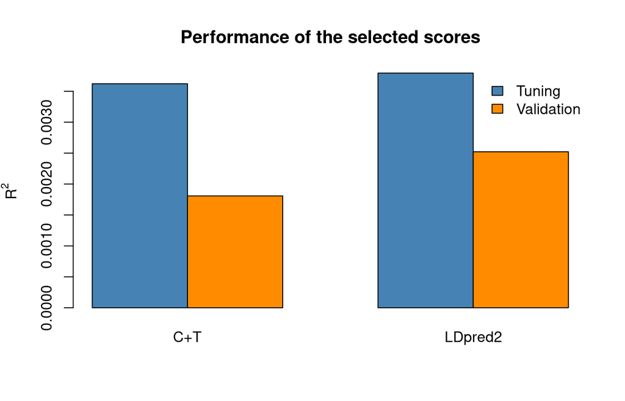

```r
barplot(rbind(comparison$tuning_R2, comparison$validation_R2), beside = TRUE,
        names.arg = comparison$method, col = c("steelblue", "darkorange"),
        ylab = expression(R^2), legend.text = c("Tuning", "Validation"),
        args.legend = list(x = "topright", bty = "n"),
        main = "Performance of the selected scores")
```

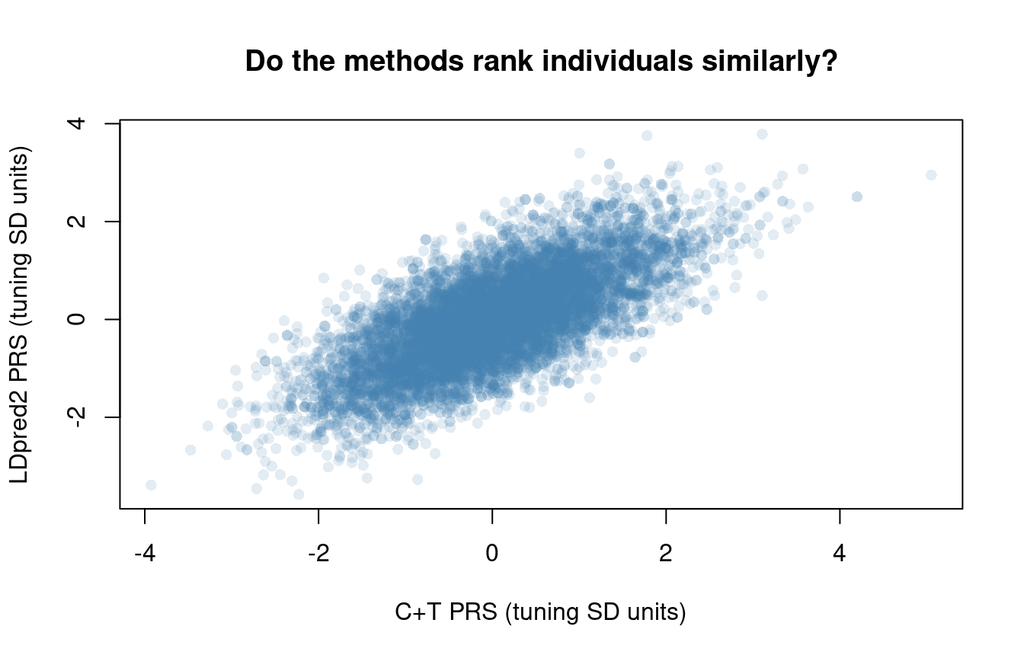

```r
standardize_from_tuning <- function(x) (x - mean(x[tuning])) / sd(x[tuning])
plot(standardize_from_tuning(best_score)[validation],
     standardize_from_tuning(best_ld_score)[validation], pch = 16,
     col = grDevices::adjustcolor("steelblue", alpha.f = 0.15),
     xlab = "C+T PRS (tuning SD units)", ylab = "LDpred2 PRS (tuning SD units)",
     main = "Do the methods rank individuals similarly?")
```

```r
cat("Correlation between validation scores:",
    round(cor(best_score[validation], best_ld_score[validation]), 4), "\n")
```

```
## Correlation between validation scores: 0.7112
```

## 9.1 Reproduction checks

After freezing the selected settings and running validation, compare your results with the tested example:

| Method | Selected setting | Scored SNPs | Validation R-squared |
| --- | --- | --- | --- |
| C+T | P <= 0.0005 | 32 | 0.001808344 |
| LDpred2 | p = 0.01; h2 = 0.01 | 23,552 | 0.002521289 |

Both use 10,000 tuning samples and 10,000 separate validation samples. These are reproduction checks, not a general method ranking. Do not change the grid to obtain these numbers or after looking at validation results. Report different behavior or additional errors to the instructor.

## 9.2 Discussion questions

1. How does C+T’s SNP count change across p-value thresholds?
2. What information does LDpred2 use that C+T discards during clumping?
3. Which `p` and `h2` combination was selected in the tuning set? Does that establish the true causal fraction or heritability? Explain why not.
4. Do the selected scores rank individuals similarly? Why can performance differ even when the same input files and sample split are used?
5. Why would selecting settings using validation outcomes give an optimistic performance estimate?
6. What could change with a larger LD reference, all chromosomes, covariates, or an ancestry-mismatched discovery or reference population?

This chromosome 22 exercise illustrates two workflows. The small European reference and restricted variant set limit generalization. Neither result is an estimate of clinical performance, and LDpred2 is not guaranteed to outperform C+T in this example. PRS-CS can be discussed as another LD-aware Bayesian method, without adding a third software workflow to this 90-minute lab.

# 10 Optional instructor appendix: build the LD input before class

This step is outside the 90-minute lab. It calculates LD from the same reference individuals and the complete eligible variant pool used above. No variants are removed merely to shorten the classroom exercise.

To create or replace the LD input, set `ldpred_mode: "fit"`, `rebuild_ld: true`, and `ld_file` to the desired output path in the YAML header. Save the Rmd and run it from the start. The `ldpred-fit` chunk calls the builder below, saves the portable sparse matrix and metadata, and continues with fitting and scoring. The parent directory of `ld_file` must already exist. Rebuilding can take substantially longer than fitting.

After a successful instructor run, restore `rebuild_ld: false` and `ldpred_mode: "prepared"`, then save the Rmd before distributing it. Provide the saved LD file and the prepared-score backup, renamed as shown above. Test both prepared mode and optional live loading in a fresh session. Both files must match the supplied data and analysis settings.

The portable LD file contains matrix values and metadata, without paths to the instructor’s temporary genotype or SFBM files. Each student creates an SFBM after loading it. On Biowulf, the code uses the job’s `/lscratch/<SLURM_JOB_ID>` directory when it exists and passes a write check. This also works when RStudio’s `tempdir()` was initialized elsewhere. Request local scratch when launching RStudio. If no writable job scratch directory is available, the code uses the R session’s temporary directory instead. The output prints the temporary LD file’s location. These temporary files are not part of the distributed LD input. Software versions record how LD was calculated; they are not required to equal the student’s versions.

```r
choose_ld_tempdir <- function(job_id = Sys.getenv("SLURM_JOB_ID"),
                             scratch_root = "/lscratch") {
  if (length(job_id) == 1L && !is.na(job_id) && grepl("^[0-9]+$", job_id)) {
    scratch <- file.path(scratch_root, job_id)
    if (dir.exists(scratch) && file.access(scratch, 2L) == 0L) {
      probe <- tempfile("PRS_LD_write_test_", tmpdir = scratch)
      if (isTRUE(suppressWarnings(file.create(probe)))) {
        unlink(probe)
        return(normalizePath(scratch))
      }
    }
  }
  tempdir()
}

validate_ld_bundle <- function(bundle, manifest, params, input_md5) {
  expected_variants <- as.data.frame(manifest[, .(CHR, SNP, BP, A1, A2)])
  expected_settings <- params[c("ld_window_kb", "ld_shrink", "ref_maf", "ref_geno")]
  expected_reference <- input_md5[c("ref_bed", "ref_bim", "ref_fam")]
  if (!is.list(bundle) || !identical(bundle$schema, 1L) ||
      !identical(bundle$variants, expected_variants) ||
      !identical(bundle$reference_md5, expected_reference) ||
      !identical(bundle$settings, expected_settings) ||
      !identical(bundle$shrinkage_applied, TRUE)) {
    stop("The LD file does not match the reference, variants, alleles, or LD settings.")
  }
  if (!is.character(bundle$versions) ||
      !all(c("bigsnpr", "bigsparser", "Matrix") %in% names(bundle$versions)) ||
      anyNA(bundle$versions) || any(!nzchar(bundle$versions)) ||
      !is.character(bundle$created) || length(bundle$created) != 1L ||
      is.na(bundle$created) || !nzchar(bundle$created)) {
    stop("The LD file is missing software-version or creation metadata.")
  }
  x <- bundle$corr
  if (!inherits(x, "dsCMatrix") || !identical(x@uplo, "U") ||
      !isTRUE(methods::validObject(x, test = TRUE)) ||
      !identical(dim(x), c(nrow(manifest), nrow(manifest)))) {
    stop("The LD file must contain a valid upper-triangle symmetric sparse matrix of the expected size.")
  }
  if (any(!is.finite(x@x)) || any(abs(x@x) > 1 + 1e-8) ||
      any(abs(Matrix::diag(x) - 1) > 1e-8)) {
    stop("The LD file contains invalid correlations or a non-unit diagonal.")
  }
  invisible(TRUE)
}

shrink_ld_offdiagonal <- function(corr_sparse, shrink) {
  if (!inherits(corr_sparse, "dsCMatrix") || !identical(corr_sparse@uplo, "U") ||
      length(shrink) != 1L || !is.numeric(shrink) || !is.finite(shrink) ||
      shrink <= 0 || shrink > 1) stop("Invalid LD matrix or shrinkage factor.")
  # In a valid upper-triangle CSC matrix, a stored diagonal is the final
  # entry in its column. Check that every column has that unit diagonal.
  diagonal_positions <- corr_sparse@p[-1L]
  if (any(diff(corr_sparse@p) < 1L) ||
      !identical(corr_sparse@i[diagonal_positions], seq_len(ncol(corr_sparse)) - 1L) ||
      any(!is.finite(corr_sparse@x[diagonal_positions])) ||
      any(abs(corr_sparse@x[diagonal_positions] - 1) > 1e-8)) {
    stop("Expected a stored unit diagonal in every LD column.")
  }
  # Equivalent to shrink * R + (1 - shrink) * I without sparse addition.
  corr_sparse@x <- shrink * corr_sparse@x
  corr_sparse@x[diagonal_positions] <- 1
  corr_sparse@factors <- list()
  corr_sparse
}

build_ld_bundle <- function(common_ref, manifest, params, input_md5, threads, run_dir) {
  genotype_rds <- bigsnpr::snp_readBed(paste0(common_ref, ".bed"),
                                     backingfile = tempfile("reference_matrix_", tmpdir = run_dir))
  reference <- bigsnpr::snp_attach(genotype_rds)
  G <- reference$genotypes
  stopifnot(identical(as.character(reference$map$marker.ID), manifest$SNP),
            identical(as.character(reference$map$allele1), manifest$A1),
            identical(as.character(reference$map$allele2), manifest$A2))
  corr_sparse <- bigsnpr::snp_cor(G, size = params$ld_window_kb,
                                 infos.pos = manifest$BP, ncores = threads)
  rm(G, reference)
  invisible(gc())
  if (any(!is.finite(corr_sparse@x)) || any(abs(Matrix::diag(corr_sparse) - 1) > 1e-8)) {
    stop("Invalid LD correlations; inspect reference genotypes.")
  }
  corr_sparse <- shrink_ld_offdiagonal(corr_sparse, params$ld_shrink)
  invisible(gc())
  bundle <- list(schema = 1L, corr = corr_sparse,
    variants = as.data.frame(manifest[, .(CHR, SNP, BP, A1, A2)]),
    reference_md5 = input_md5[c("ref_bed", "ref_bim", "ref_fam")],
    settings = params[c("ld_window_kb", "ld_shrink", "ref_maf", "ref_geno")],
    shrinkage_applied = TRUE,
    versions = vapply(c("bigsnpr", "bigsparser", "Matrix"),
                      function(pkg) as.character(packageVersion(pkg)), character(1)),
    created = as.character(Sys.time()))
  validate_ld_bundle(bundle, manifest, params, input_md5)
  bundle
}
```

[session information not shown]

```r
cat("Saved results:", run_dir, "\n")
```

```
## Saved results: /vf/users/wongs6/statgen_workshop_2026/PRS_tutorial_Wendy_2026-10-27/publishing/interactive_setup_2026-10-28/prepared_results/run_20261028_110801_2526d71a729ffa
```

Results are from the current run. PLINK `.log` files and `.console.log` files contain variant counts, warnings, and versions; `.sh` files record the commands. `parameters.rds` records the initial run configuration; `parameters_effective.rds` records the current LDpred2 configuration, including an interactive switch to prepared mode.

If something fails, send the instructor the **chunk name**, **exact error or warning**, your R/package versions from `sessionInfo()`, and the relevant log from the printed run directory. You do not need to send raw genotype files.

Documentation: [PLINK 1.9 clumping](https://www.cog-genomics.org/plink/1.9/postproc#clump), [PLINK 2 scoring](https://www.cog-genomics.org/plink/2.0/score), and [Biowulf PLINK modules](https://hpc.nih.gov/apps/plink.html). LDpred2: [official tutorial](https://privefl.github.io/bigsnpr/articles/LDpred2.html), [function reference](https://privefl.github.io/bigsnpr/reference/LDpred2.html), [LD calculation](https://privefl.github.io/bigsnpr/reference/snp_cor.html), and [original paper](https://doi.org/10.1093/bioinformatics/btaa1029).